# Precipitation and Drought Records Collection

- Show All Code
- Hide All Code
- View Source

10-Year Historical Records for South Dakota and Oglala Lakota County

Author

Antigravity Coding Assistant

Published

July 19, 2026

# Introduction

This document contains Python code to programmatically retrieve, process, and store 10 years of historical data for: 1. **Weekly Drought Monitor records** for Oglala Lakota County, South Dakota (FIPS 46102). 2. **Daily Precipitation records** for the State of South Dakota (state-wide mean).

The collected datasets are saved to the `data/` directory as: - `data/oglala_lakota_drought_weekly.csv` - `data/south_dakota_precipitation_daily.csv`

# Data Sources & Citations

1. **U.S. Drought Monitor (USDM)**
   - **Source**: National Drought Mitigation Center (NDMC), University of Nebraska-Lincoln, USDA, and NOAA.
   - **Description**: Weekly reports of drought severity classifications (None, D0-D4) indicating the percentage of area affected.
   - **Data Access**: Retrieved via the USDM REST Data Services API: `https://usdmdataservices.unl.edu/api/`.
   - **Citation**: > U.S. Drought Monitor. (2026). *U.S. Drought Monitor data archives*. National Drought Mitigation Center. Retrieved from https://droughtmonitor.unl.edu/
2. **Applied Climate Information System (ACIS)**
   - **Source**: NOAA Regional Climate Centers (RCCs).
   - **Description**: Daily precipitation observations aggregated and interpolated across the state of South Dakota, computed as a statewide mean.
   - **Data Access**: Retrieved via the ACIS GridData API: `https://data.rcc-acis.org/GridData`.
   - **Citation**: > Applied Climate Information System (ACIS). (2026). *Gridded Daily Precipitation (NRCC Interpolated Grid)*. NOAA Regional Climate Centers. Retrieved from https://www.rcc-acis.org/

# Data Collection Pipeline

The following Python block dynamically computes the date range for the past 10 years and calls the respective APIs to fetch and store the records.

```python
import os
import io
import datetime
import requests
import pandas as pd

# Create target data directory
os.makedirs("data", exist_ok=True)

# Calculate dynamic dates for the past 10 years
today = datetime.date.today()
try:
    start_date = today.replace(year=today.year - 10)
except ValueError:
    # Handle leap year edge case (Feb 29)
    start_date = today.replace(year=today.year - 10, day=28)

start_date_str = start_date.strftime("%Y-%m-%d")
end_date_str = today.strftime("%Y-%m-%d")

print(f"Collection timeframe: {start_date_str} to {end_date_str}")

# --- Task 1: Fetch U.S. Drought Monitor Data for Oglala Lakota County (FIPS 46102) ---
fips_code = "46102"
usdm_url = (
    f"https://usdmdataservices.unl.edu/api/CountyStatistics/GetDroughtSeverityStatisticsByAreaPercent"
    f"?aoi={fips_code}&startdate={start_date_str}&enddate={end_date_str}&statisticsType=1"
)

print(f"Querying USDM API...")
usdm_response = requests.get(usdm_url)
if usdm_response.status_code == 200:
    usdm_csv = usdm_response.text
    usdm_path = os.path.join("data", "oglala_lakota_drought_weekly.csv")
    with open(usdm_path, "w", encoding="utf-8") as f:
        f.write(usdm_csv)
    print(f"-> Successfully saved weekly drought data to {usdm_path}")
else:
    print(f"-> Error fetching USDM data: {usdm_response.status_code}")
    print(usdm_response.text[:500])

# --- Task 2: Fetch Daily Precipitation Records for South Dakota (State Mean) ---
acis_url = "https://data.rcc-acis.org/GridData"
acis_payload = {
    "state": "sd",
    "sdate": start_date_str,
    "edate": end_date_str,
    "grid": "1",
    "elems": [{"name": "pcpn", "area_reduce": "state_mean"}]
}

print(f"Querying ACIS GridData API...")
acis_response = requests.post(acis_url, json=acis_payload)
if acis_response.status_code == 200:
    acis_json = acis_response.json()
    raw_records = acis_json.get("data", [])

    # Process the nested list format into a standard DataFrame
    processed = []
    for date_val, val_dict in raw_records:
        val = val_dict.get("SD") if isinstance(val_dict, dict) else None
        # Handle potential trace ('T') or missing ('M') string codes
        if val is None or val in ["M", "M ", " M", ""]:
            val_float = None
        elif val == "T" or val == "T ":
            val_float = 0.0001
        else:
            try:
                val_float = float(val)
            except ValueError:
                val_float = None
        processed.append({"date": date_val, "precipitation_inches": val_float})

    df_precip = pd.DataFrame(processed)
    precip_path = os.path.join("data", "south_dakota_precipitation_daily.csv")
    df_precip.to_csv(precip_path, index=False)
    print(f"-> Successfully saved daily precipitation data to {precip_path}")
else:
    print(f"-> Error fetching ACIS data: {acis_response.status_code}")
    print(acis_response.text[:500])
```

```
Collection timeframe: 2016-07-19 to 2026-07-19
Querying USDM API...
-> Successfully saved weekly drought data to data/oglala_lakota_drought_weekly.csv
Querying ACIS GridData API...
-> Successfully saved daily precipitation data to data/south_dakota_precipitation_daily.csv
```

# Data Previews & Summaries

Let’s load the saved datasets to verify their content and print summary statistics.

## U.S. Drought Monitor Data Summary

```python
df_usdm = pd.read_csv("data/oglala_lakota_drought_weekly.csv")

# Clean dates and sort chronologically
df_usdm["ValidStart"] = pd.to_datetime(df_usdm["ValidStart"])
df_usdm["ValidEnd"] = pd.to_datetime(df_usdm["ValidEnd"])
df_usdm = df_usdm.sort_values("ValidStart").reset_index(drop=True)

print(f"Number of weekly USDM records: {len(df_usdm)}")
df_usdm[["ValidStart", "County", "None", "D0", "D1", "D2", "D3", "D4"]].tail()
```

```
Number of weekly USDM records: 522
```

|  | ValidStart | County | None | D0 | D1 | D2 | D3 | D4 |
| --- | --- | --- | --- | --- | --- | --- | --- | --- |
| 517 | 2026-06-16 | Oglala Lakota County | 0.0 | 100.0 | 100.0 | 97.83 | 34.58 | 0.0 |
| 518 | 2026-06-23 | Oglala Lakota County | 0.0 | 100.0 | 100.0 | 97.83 | 34.58 | 0.0 |
| 519 | 2026-06-30 | Oglala Lakota County | 0.0 | 100.0 | 100.0 | 97.83 | 18.48 | 0.0 |
| 520 | 2026-07-07 | Oglala Lakota County | 0.0 | 100.0 | 100.0 | 97.83 | 18.48 | 0.0 |
| 521 | 2026-07-14 | Oglala Lakota County | 0.0 | 100.0 | 100.0 | 97.83 | 18.48 | 0.0 |

### Drought Summary Stats

```python
df_usdm[["None", "D0", "D1", "D2", "D3", "D4"]].describe()
```

|  | None | D0 | D1 | D2 | D3 | D4 |
| --- | --- | --- | --- | --- | --- | --- |
| count | 522.000000 | 522.000000 | 522.000000 | 522.000000 | 522.000000 | 522.0 |
| mean | 34.515670 | 65.484330 | 47.302778 | 17.747835 | 4.817050 | 0.0 |
| std | 46.187019 | 46.187019 | 46.171407 | 32.746903 | 16.674187 | 0.0 |
| min | 0.000000 | 0.000000 | 0.000000 | 0.000000 | 0.000000 | 0.0 |
| 25% | 0.000000 | 0.000000 | 0.000000 | 0.000000 | 0.000000 | 0.0 |
| 50% | 0.000000 | 100.000000 | 42.270000 | 0.000000 | 0.000000 | 0.0 |
| 75% | 100.000000 | 100.000000 | 100.000000 | 13.580000 | 0.000000 | 0.0 |
| max | 100.000000 | 100.000000 | 100.000000 | 100.000000 | 97.570000 | 0.0 |

## Daily Precipitation Data Summary

```python
df_precip = pd.read_csv("data/south_dakota_precipitation_daily.csv")
df_precip["date"] = pd.to_datetime(df_precip["date"])
df_precip = df_precip.sort_values("date").reset_index(drop=True)

print(f"Number of daily precipitation records: {len(df_precip)}")
df_precip.tail()
```

```
Number of daily precipitation records: 3653
```

|  | date | precipitation_inches |
| --- | --- | --- |
| 3648 | 2026-07-15 | 0.000000 |
| 3649 | 2026-07-16 | 0.000415 |
| 3650 | 2026-07-17 | 0.008933 |
| 3651 | 2026-07-18 | 0.006323 |
| 3652 | 2026-07-19 | 0.018227 |

### Precipitation Summary Stats

```python
df_precip["precipitation_inches"].describe()
```

```
count    3653.000000
mean        0.059834
std         0.123767
min         0.000000
25%         0.000671
50%         0.008933
75%         0.056138
max         1.374540
Name: precipitation_inches, dtype: float64
```

# Visualizations

Let’s visualize the trends over the 10-year period.

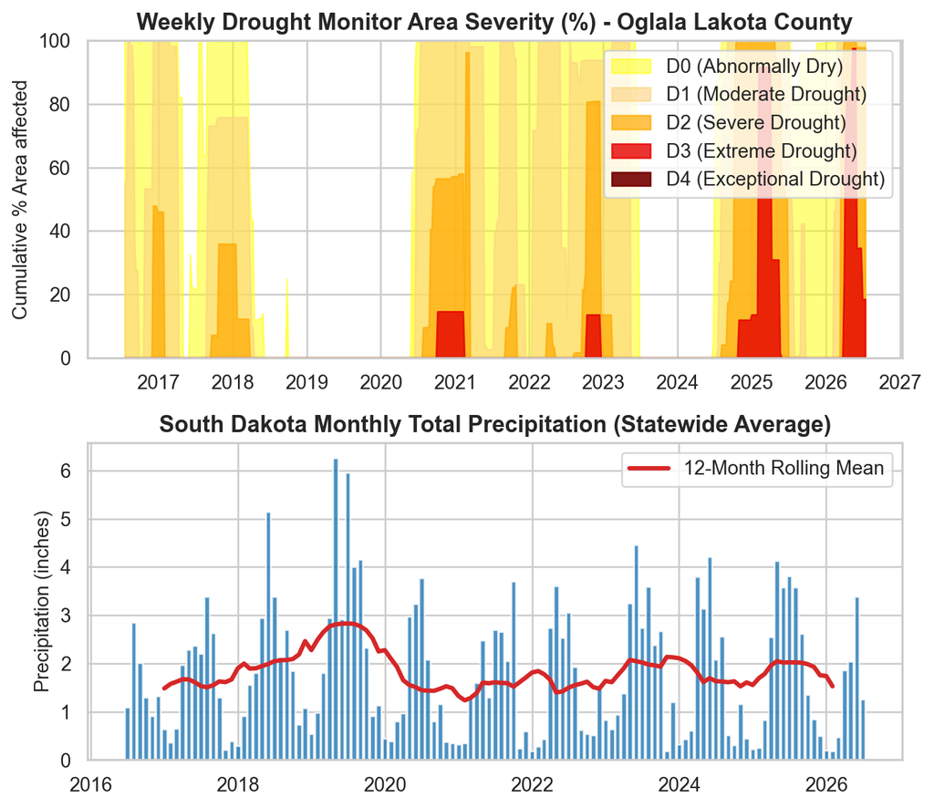

```python
import matplotlib.pyplot as plt
import seaborn as sns

sns.set_theme(style="whitegrid")
fig, axes = plt.subplots(2, 1, figsize=(7.5, 6.5), sharex=False)

# 1. Plot Weekly Drought Monitor Trends (Cumulative Area Percentage)
# D0: Abnormally Dry, D1: Moderate, D2: Severe, D3: Extreme, D4: Exceptional
axes[0].fill_between(df_usdm["ValidStart"], df_usdm["D0"], color="#ffff00", alpha=0.5, label="D0 (Abnormally Dry)")
axes[0].fill_between(df_usdm["ValidStart"], df_usdm["D1"], color="#fcd37f", alpha=0.6, label="D1 (Moderate Drought)")
axes[0].fill_between(df_usdm["ValidStart"], df_usdm["D2"], color="#ffaa00", alpha=0.7, label="D2 (Severe Drought)")
axes[0].fill_between(df_usdm["ValidStart"], df_usdm["D3"], color="#e60000", alpha=0.8, label="D3 (Extreme Drought)")
axes[0].fill_between(df_usdm["ValidStart"], df_usdm["D4"], color="#730000", alpha=0.9, label="D4 (Exceptional Drought)")
axes[0].set_title("Weekly Drought Monitor Area Severity (%) - Oglala Lakota County", fontsize=13, fontweight="bold")
axes[0].set_ylabel("Cumulative % Area affected", fontsize=11)
axes[0].set_ylim(0, 100)
axes[0].legend(loc="upper right", frameon=True)

# 2. Plot Monthly Aggregated Precipitation (for cleaner visualization)
df_precip["year_month"] = df_precip["date"].dt.to_period("M")
df_monthly = df_precip.groupby("year_month")["precipitation_inches"].sum().reset_index()
df_monthly["date_index"] = df_monthly["year_month"].dt.to_timestamp()

axes[1].bar(df_monthly["date_index"], df_monthly["precipitation_inches"], width=25, color="#1f77b4", alpha=0.8)
# Plot a 12-month rolling mean to show trends
df_monthly["rolling_mean"] = df_monthly["precipitation_inches"].rolling(12, center=True).mean()
axes[1].plot(df_monthly["date_index"], df_monthly["rolling_mean"], color="#d62728", linewidth=2.5, label="12-Month Rolling Mean")

axes[1].set_title("South Dakota Monthly Total Precipitation (Statewide Average)", fontsize=13, fontweight="bold")
axes[1].set_ylabel("Precipitation (inches)", fontsize=11)
axes[1].legend(loc="upper right", frameon=True)

plt.tight_layout()
plt.show()
```